# Additional downstream analysis: differential neighborhood networks

CellCharterR contributors

2026-10-22

# 1 Purpose

This is the third CellCharterR tutorial. Begin with the [beginner workflow](https://cperalta-viteri.github.io/CellCharterR/docs/CellCharterR-beginner-workflow.html), then consult the [full mouse-spleen reproduction](https://cperalta-viteri.github.io/CellCharterR/docs/CellCharterR-mouse-spleen-reproducibility.html) for graph construction, aggregation, AutoK, and both reported resolutions.

This tutorial starts from the official CODEX mouse-spleen datasets, shows their `SpatialExperiment` representation, prepares a biologically useful dominant cell-type annotation, and demonstrates the additional downstream workflow using the compiled C++ AutoK-selected **K = 10** domains. The expensive full-data results are loaded from preserved package artifacts, so installation and vignette rendering never rerun clustering or the 100 sample-level permutations.

The compiled C++ CPU GMM/AutoK backend is the supported path used for these saved domains. This tutorial starts after clustering, with labels stored in `colData(spe)` or a `reducedDim`. Graph construction, enrichment, neighborhood enrichment, differential testing, and plotting remain native R workflows.

The stored contrast is BALBc minus MRL. Rows of each matrix represent the source or central domain, columns represent the surrounding or neighboring domain, and arrows therefore point **source -> neighbor**. Positive effects are shown in the BALBc panel; negative effects are displayed by absolute magnitude in the MRL panel. Both panels reuse the same permutation p-values.

# 2 Import the mouse-spleen data as a SpatialExperiment

Start from the completed AnnData/H5AD object. CellCharterR’s migration tool copies its contents into an independent, resumable, disk-backed directory and returns a native `SpatialExperiment`. It does not require Python, `anndataR`, `zellkonverter`, or R 4.5. The source H5AD remains untouched and is no longer needed after the directory has been validated.

The code is not executed while building this vignette because the official mouse-spleen H5AD is hundreds of MiB. The [large-data workflow](https://cperalta-viteri.github.io/CellCharterR/docs/CellCharterR-h5ad-to-sce.html) gives the complete download, checksum, and storage details.

```r
library(CellCharterR)

spe_dir <- "data/codex_mouse_spleen_spe"

spe <- cellcharter_import_h5ad(
  h5ad_file = "data-raw/codex_mouse_spleen_clustered.h5ad",
  output_dir = spe_dir
)

# `cellcharter_import_h5ad()` has now created an independent SPE directory and
# returned its live SPE. The whole directory is the object.
stopifnot(dir.exists(spe_dir))

# In a later R session, or after moving the complete directory:
rm(spe)
spe <- cellcharter_load_spe(spe_dir)
methods::validObject(spe)
```

The migrated full object contains 707,474 spatial spots. Protein expression, AUCell-like score matrices, and supplied embeddings can remain disk-backed. AnnData `obs` variables become `colData`, `obsm` matrices become reduced dimensions, and spatial coordinates use the native `spatialCoords()` slot.

```r
spe
dim(spe)
SummarizedExperiment::assayNames(spe)
colnames(SummarizedExperiment::colData(spe))
SingleCellExperiment::reducedDimNames(spe)
SpatialExperiment::spatialCoordsNames(spe)
SingleCellExperiment::colPairNames(spe)

# The released H5AD carries the published K=11 reference labels.
table(spe$cluster_cellcharter)
```

After the graph and precomputed domain labels are added, the recommended object organization is:

```
class: SpatialExperiment
dimensions: 29 proteins × 707,474 spatial spots
assays: protein (disk-backed)
spatialCoords: spatial (x, y)
reducedDims: X_trVAE, X_cellcharter
colData: sample, condition, cell_type, cluster_cellcharter,
         cellcharter_domain_cpp_k10 (attached below)
colPairs: spatial_connectivities, spatial_distances,
          cellcharter_graph_pinned_global (rebuilt below)
metadata: CellCharterR results and provenance
```

Domain labels do not require a special registration function. Migration places the published H5AD’s `cluster_cellcharter` variable directly in `colData(spe)`. The independently selected C++ K=10 labels are a different result, so the next section attaches their preserved, order-validated package artifact under a new name. Downstream functions can read `domain_col` from `colData`, a one-column `reducedDim`, or an unambiguous named reducedDim column.

# 3 Use the detailed assigned cell type

The CODEX H5AD already contains one detailed assigned cell type per segmented cell. That `cell_type` field is the exact annotation used to generate the preserved 27-row enrichment artifact below. No relabelling or collapsing is performed in this reproduction.

```r
stopifnot("cell_type" %in% colnames(SummarizedExperiment::colData(spe)))
table(spe$cell_type)
```

# 4 Preserve the imported graph and reconstruct the primary-analysis graph

Migration preserves AnnData `obsp["spatial_connectivities"]` and `obsp["spatial_distances"]` as named SPE `colPairs`; the first block verifies that handoff. The released H5AD graph, however, applies a 99th-percentile edge cutoff within each sample. The preserved C++ K=10 result used sample-local Delaunay graphs followed by one global 99th-percentile cutoff, matching the pinned CellCharter 0.2.0 implementation. These graphs are both retained, but they are not interchangeable.

```r
SingleCellExperiment::colPairNames(spe)
spatial_graph <- SingleCellExperiment::colPair(
  spe,
  "spatial_connectivities",
  asSparse = TRUE
)
dim(spatial_graph)
```

Reconstruct the exact graph contract used by the C++ K=10 downstream artifacts:

```r
spe <- cellcharter_graph(
  spe,
  spatial = "spatial",
  sample_col = "sample",
  graph_name = "cellcharter_graph_pinned_global",
  percentile = 99
)
```

# 5 Attach the independently selected C++ K=10 labels

The released H5AD stores the publication’s K=11 labels, not the independent R K=10 result. CellCharterR therefore ships the compact C++ K=10 label vector with an ordered-cell SHA-256 digest. The assignment stops rather than silently pairing labels with a differently ordered SPE.

```r
cpp_labels <- readRDS(
  system.file(
    "extdata", "mouse_spleen_cpp_k10_labels.rds",
    package = "CellCharterR", mustWork = TRUE
  )
)
observed_order <- digest::digest(
  as.character(colnames(spe)), algo = "sha256"
)
stopifnot(
  length(cpp_labels$labels) == ncol(spe),
  identical(observed_order, cpp_labels$cell_order_sha256),
  identical(cpp_labels$k, 10L),
  identical(cpp_labels$backend, "compiled-cpp-double"),
  identical(
    cpp_labels$graph_source,
    "R-native Qhull with pinned CellCharter 0.2.0 global cutoff"
  )
)
spe$cellcharter_domain_cpp_k10 <- factor(cpp_labels$labels, levels = 0:9)
```

The illustrative result compares three BALBc libraries with six MRL libraries, uses sample as the permutation unit, and contains 100 permutations under the pinned CellCharter 0.2.0 compatibility mode.

# 6 Compute cell-type enrichment

With detailed cell types and precomputed C++ K=10 domains in the SPE, the complete computation is one call. This code is shown but not rerun here; the following figure loads its preserved result. The visible checks make the loaded artifact’s biological grouping and permutation contract explicit.

```r
spe <- cellcharter_enrichment(
  spe,
  group_col = "cell_type",
  domain_col = "cellcharter_domain_cpp_k10",
  result_name = "cell_type_enrichment",
  log2_fold_change = TRUE
)
```

```r
stopifnot(
  nrow(cpp_enrichment$enrichment) == 27L,
  identical(cpp_labels$k, 10L),
  identical(cpp_labels$backend, "compiled-cpp-double"),
  identical(cpp_result$params$n_perms, 100L),
  identical(cpp_result$params$seed, 0L),
  identical(cpp_result$params$library_unit, "sample")
)
c(
  domains = cpp_labels$k,
  detailed_cell_types = nrow(cpp_enrichment$enrichment),
  permutations = cpp_result$params$n_perms
)
```

```
#>             domains detailed_cell_types        permutations
#>                  10                  27                 100
```

## 6.1 Meet the spatial ecosystems

Before interpreting connections between domains, first inspect which cell types characterize each domain. The dot plot shows positive observed-to-expected cell-type enrichment as log2 fold change. Darker and larger red points indicate stronger positive enrichment; non-positive values remain in the stored result but are omitted from this display, following the CellCharter presentation.

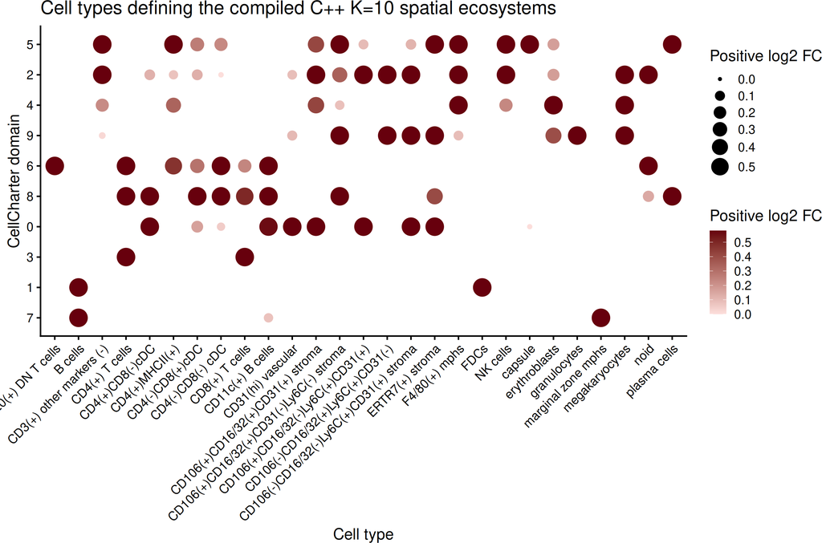

Figure 1: Cell-type enrichment defining the ten compiled C++ K=10 mouse-spleen spatial ecosystems

```r
CellCharterR::cellcharter_plot_enrichment(
  cpp_enrichment,
  title = "Cell types defining the compiled C++ K=10 spatial ecosystems"
)
```

These enrichment profiles provide the biological context for the numbered nodes below: each network node is one of these ten spatial ecosystems, not an individual cell type.

# 7 Spatial-neighborhood enrichment in healthy and lupus spleen

The differential result retains the complete observed, expected, and observed-minus-expected matrices for BALBc and MRL. The heatmaps below show the condition-specific directed neighborhood enrichment before taking their contrast. Rows are central ecosystems and columns are their neighbors.

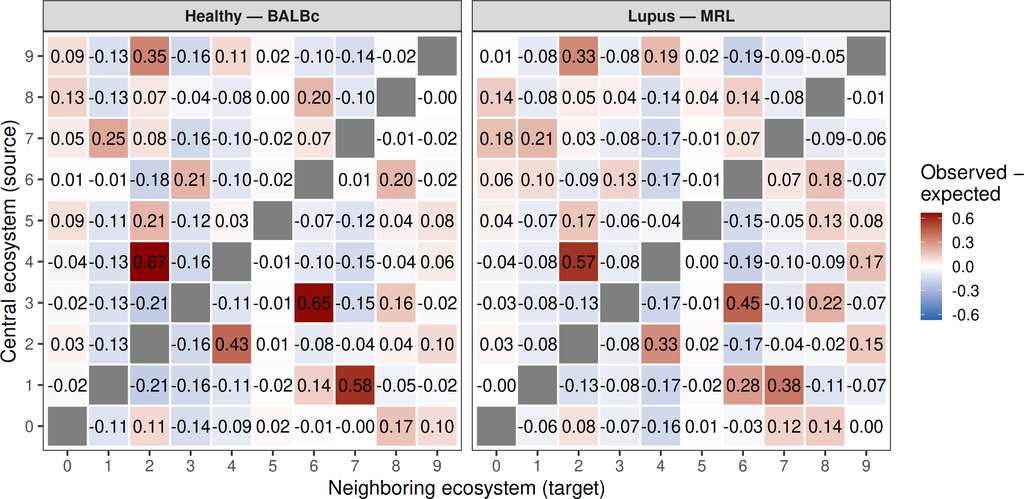

Figure 2: Directed compiled C++ K=10 spatial-neighborhood enrichment in healthy BALBc and lupus MRL mouse spleen

```r
neighborhood_long <- function(x, condition) {
  value <- as.data.frame(as.table(x), stringsAsFactors = FALSE)
  names(value) <- c("source", "target", "enrichment")
  value$condition <- condition
  value$label <- ifelse(is.finite(value$enrichment), sprintf("%.2f", value$enrichment), "")
  value
}

condition_neighborhood <- rbind(
  neighborhood_long(cpp_result$enrichment$BALBc, "Healthy — BALBc"),
  neighborhood_long(cpp_result$enrichment$MRL, "Lupus — MRL")
)
neighborhood_limit <- max(abs(condition_neighborhood$enrichment), na.rm = TRUE)

ggplot2::ggplot(
  condition_neighborhood,
  ggplot2::aes(x = target, y = source, fill = enrichment)
) +
  ggplot2::geom_tile(colour = "white", linewidth = 0.8) +
  ggplot2::geom_text(ggplot2::aes(label = label), size = 5) +
  ggplot2::facet_wrap(~condition, nrow = 1) +
  ggplot2::scale_fill_gradient2(
    low = "#2166AC", mid = "white", high = "#8B0000",
    midpoint = 0, limits = c(-neighborhood_limit, neighborhood_limit),
    name = "Observed −\nexpected"
  ) +
  ggplot2::coord_fixed() +
  ggplot2::labs(
    x = "Neighboring ecosystem (target)",
    y = "Central ecosystem (source)"
  ) +
  ggplot2::theme_bw(base_size = 16) +
  ggplot2::theme(
    panel.grid = ggplot2::element_blank(),
    strip.text = ggplot2::element_text(face = "bold")
  )
```

The corresponding full computation uses the graph, domain labels, biological condition, and sample/library identifiers. Sample is the permutation unit.

```r
spe <- cellcharter_diff_nhood_enrichment(
  spe,
  graph_name = "cellcharter_graph_pinned_global",
  domain_col = "cellcharter_domain_cpp_k10",
  condition_col = "condition",
  sample_col = "sample",
  condition_groups = c("BALBc", "MRL"),
  n_perms = 100L,
  seed = 0L,
  permutation_mode = "cellcharter_v0.2.0",
  result_name = "BALBc_vs_MRL"
)
```

# 8 Inspect both differential contrasts

Before reducing the result to arrows, inspect the complete directed effect matrices. The stored effect is BALBc minus MRL; the reciprocal display negates that effect while retaining the same directional empirical p-values. Rows are source ecosystems and columns are neighboring target ecosystems. A star marks an empirical `p <= 0.05` from the 100 sample-level permutations.

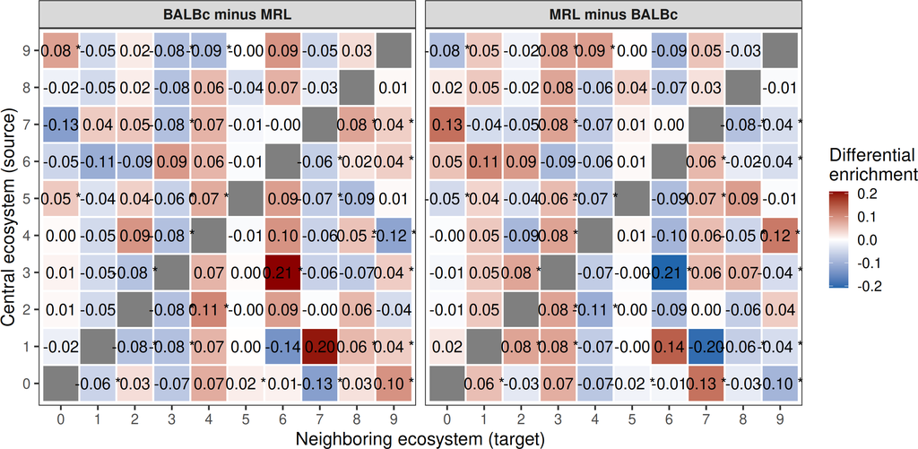

Figure 3: Full compiled C++ K=10 differential neighborhood-enrichment matrices in both display directions

```r
contrast_long <- function(effect, pvalue, contrast) {
  value <- as.data.frame(as.table(effect), stringsAsFactors = FALSE)
  names(value) <- c("source", "target", "effect")
  value$pvalue <- as.vector(pvalue)
  value$contrast <- contrast
  value$label <- ifelse(
    is.finite(value$effect),
    paste0(sprintf("%.2f", value$effect), ifelse(value$pvalue <= 0.05, " *", "")),
    ""
  )
  value
}

contrast_heatmaps <- rbind(
  contrast_long(cpp_result$effect, cpp_result$pvalue, "BALBc minus MRL"),
  contrast_long(-cpp_result$effect, cpp_result$pvalue, "MRL minus BALBc")
)
effect_limit <- max(abs(contrast_heatmaps$effect), na.rm = TRUE)

ggplot2::ggplot(
  contrast_heatmaps,
  ggplot2::aes(x = target, y = source, fill = effect)
) +
  ggplot2::geom_tile(colour = "white", linewidth = 0.8) +
  ggplot2::geom_text(ggplot2::aes(label = label), size = 5) +
  ggplot2::facet_wrap(~contrast, nrow = 1) +
  ggplot2::scale_fill_gradient2(
    low = "#2166AC", mid = "white", high = "#8B0000",
    midpoint = 0, limits = c(-effect_limit, effect_limit),
    name = "Differential\nenrichment"
  ) +
  ggplot2::coord_fixed() +
  ggplot2::labs(
    x = "Neighboring ecosystem (target)",
    y = "Central ecosystem (source)"
  ) +
  ggplot2::theme_bw(base_size = 16) +
  ggplot2::theme(
    panel.grid = ggplot2::element_blank(),
    strip.text = ggplot2::element_text(face = "bold")
  )
```

These heatmaps retain every directed off-diagonal comparison, including weak or unsupported effects. The network views below summarize the same matrices; they do not perform a second statistical test.

# 9 Plot the differential graph

Black arrows are the default. Solid arrows pass the displayed statistical threshold; dashed arrows are retained effects that are not statistically supported at that threshold. Arrow width is intentionally constant, so it does not create an additional visual claim about magnitude.

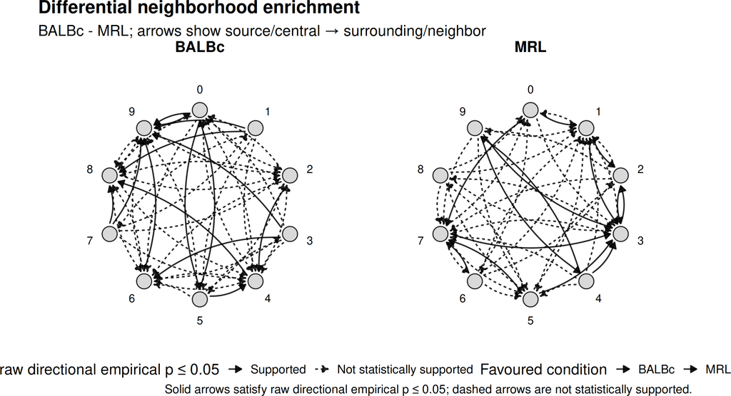

Figure 4: Full mouse-spleen compiled C++ K=10 differential neighborhood-enrichment network  
The two panels share identical node coordinates.

```r
CellCharterR::cellcharter_plot_graph_diff(cpp_result)
```

The graph is asymmetric: domain 0 -> domain 2 and domain 2 -> domain 0 are different directed hypotheses. Their effects and p-values must not be combined or interpreted as an undirected connection.

# 10 Apply user-defined condition colors

Colors are presentation choices, not part of the statistical test. A single color applies to both panels; a named vector can assign one color per condition.

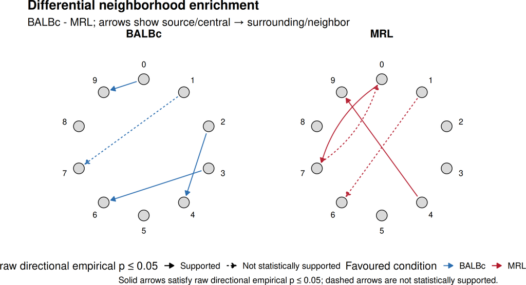

Figure 5: The same result with user-supplied condition colors and the strongest four arrows retained independently per panel

```r
CellCharterR::cellcharter_plot_graph_diff(
  cpp_result,
  edge_colours = c(BALBc = "#2166AC", MRL = "#B2182B"),
  top_n = 4
)
```

`top_n` is a display filter. It is applied independently in each panel after p-values have been evaluated and therefore does not alter the p-values or their multiple-testing adjustment.

# 11 Focus on statistically supported arrows

The reference-compatible default uses raw directional empirical p-values. For exploratory multiplicity control, select a method supported by `stats::p.adjust()`; adjustment is performed across every eligible directed off-diagonal hypothesis before display filtering.

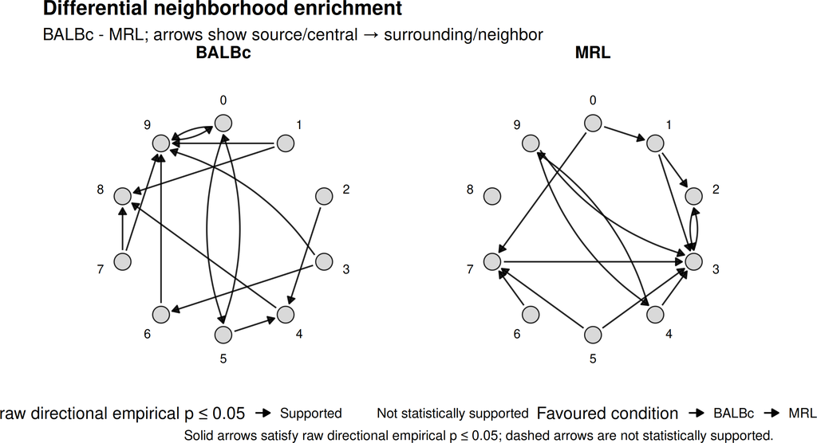

Figure 6: Edges supported by the raw directional empirical p-value threshold of 0.05

```r
CellCharterR::cellcharter_plot_graph_diff(
  cpp_result,
  significant_only = TRUE,
  alpha = 0.05
)
```

# 12 Illustrative interpretation

In this C++ K=10 result, direction, effect size, and empirical support must be read together. A recorded p-value of zero means that none of the 100 reference-compatible permutation draws was as extreme; it does **not** mean that the probability is literally zero. The complete heatmaps should be inspected before applying the network’s display filters.

These domain numbers do not themselves identify cell types or mechanisms. Biological interpretation should combine this network with the corresponding spatial maps, cell-type enrichment results, sample-level consistency, and the known limitations of the K=10 domain resolution. The figure is therefore a diagnostic summary of the computed differential neighborhood result, not proof of a causal interaction.

# 13 Reproduce the downstream analysis

The following code documents where the plotted differential result originates, but it is not run when the vignette is built. It starts from the full SPE with precomputed domains; it does not rerun the compiled C++ GMM or AutoK.

```r
spe <- cellcharter_diff_nhood_enrichment(
  spe,
  graph_name = "cellcharter_graph_pinned_global",
  domain_col = "cellcharter_domain_cpp_k10",
  condition_col = "condition",
  sample_col = "sample",
  condition_groups = c("BALBc", "MRL"),
  n_perms = 100L,
  seed = 0L,
  permutation_mode = "cellcharter_v0.2.0",
  result_name = "BALBc_vs_MRL"
)

CellCharterR::cellcharter_plot_graph_diff(spe, result_name = "BALBc_vs_MRL")
```

# 14 Save the completed downstream analysis

The import directory is already the independent SPE, including its imported graph. After adding the validated C++ K=10 labels, the pinned-global graph, and downstream results, save the mutable state back into the same directory. The large `arrays.h5` payload is neither copied nor rewritten:

```r
CellCharterR::cellcharter_save_spe(spe, spe_dir)

# Reload it in a later session or after moving the complete directory.
spe <- cellcharter_load_spe(spe_dir)
methods::validObject(spe)
```

The default `retain_generations = 1L` keeps only the latest validated state. If state restoration must be bypassed during recovery, use `cellcharter_load_spe(spe_dir, restore_state = FALSE)`. Copy or archive the complete `spe_dir`, not individual RDS or HDF5 files. AutoK/fixed-K models, stability objects, stage metadata, and checkpoint locators are omitted from the SPE state regardless of checkpoint mode. No checkpoint directory is copied into `spe_dir`; archive it separately when resume, stability inspection, or model retrieval is required. Labels in `colData` and graphs in `colPairs` remain portable with the SPE.